# An Introduction to R

23 November 2017

## Setup

## What you'll need

- R and RStudio installed on your laptop
- The `tidyverse` R package
- The *Perceptions of Uncertainty* dataset from https://tinyurl.com/probly-data (right click page and **Save as** *probly.csv*)

## Overview

- Introduction to R and RStudio
- Importing data
- Processing data
- Plotting data
- Summarising data

## Getting started

## RStudio

[figure not shown]

## RStudio

[figure not shown]

## Projects

Create a new project to keep files organised

[figure not shown]

[figure not shown]

## Notebooks

[figure not shown]

Create a new notebook in RStudio.

## Adding text to a notebook

- Simply type!
- Create sections with `#`.
- Subsections can be created with `##` and `###`.
- Highlight text by surrounding it with `*` for *italics*.
- Use `**` for **bold**.

Type some text into the notebook and experiment with formatting.

You can use the notebook to keep notes for this course.

## Learning more about Markdown

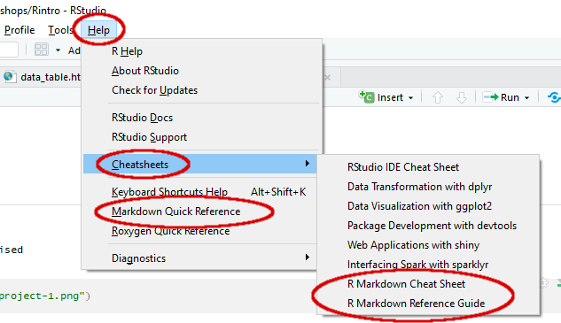

## Preview results

[figure not shown]

- Take a look at the rendered results.
- Try exporting to PDF or Word.

## Adding R code

- Blocks of R code start with `` ```{r} ``
- and end with `` ``` ``

`` ```{r} ``

`# fancy computations here`

`` ``` ``

Add a code block to your notebook.

- `Ctrl`+`Alt`+`I` may help.
- `⌘`+`Option`+`I` may help.

## Storing values

- Want to assign a name to data so we can use it in computations
- Assign values to variables
- Values can be simple (e.g. `5` or `"dog"`)
- … or complex (e.g. all the data from your study)

```r
ans <- 42
```

Add a variable assignment to your code chunk.

## Executing R code

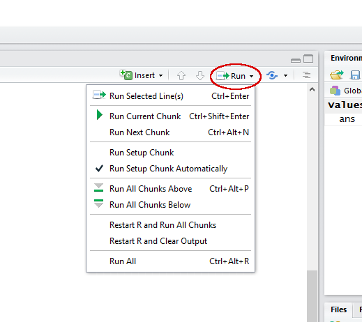

Execute current line of code:

- `Ctrl`+`Enter`
- `⌘`+`Enter`

Execute entire code block:

- `Ctrl`+`Shift`+`Enter`
- `⌘`+`Shift`+`Enter`

## Chunk options

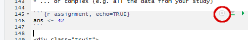

- Behaviour of R chunks can be modified through options.
- Access via settings icon or type directly into chunk header.
- Can name chunks to make locating them later easier.

## Examining values

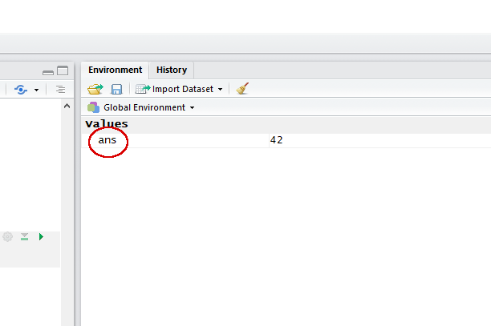

- View values in the *Environment* window.
- Use the data viewer
  - Try `View(ans)`
- `print` values
  - Try `print(ans)`
- Highlight variable name in notebook + `Ctrl`+`Enter`

## Basic building blocks – Vectors

- Data is stored in vectors
- Each vector has a *type*
  - *numeric* for interval and ratio data
  - *logical* for binary data/truth values
  - *character* or *factor* for categorical data
  - …

```r
1:5
logical(3)
letters
factor(letters)
```

## Basic building blocks – Vectors

- Vectors can have multiple dimensions.

```r
mat <- matrix(1:12, ncol=3)
dim(mat)
mat[2, 3]
```

## Basic building blocks – Vectors

- Different types of vectors can be combined into *lists*.
- Vectors of the same length can be combined into *data frames*.

```r
lst <- list(position=1:26, letter=letters)
lst[[2]][3]
lst$letter[3]
df <- data.frame(position=1:26, letter=letters)
df[3, 2]
df[-(1:10),]
```

## Basic building blocks – Functions

- Functions transform data.
- Input remains unchanged.

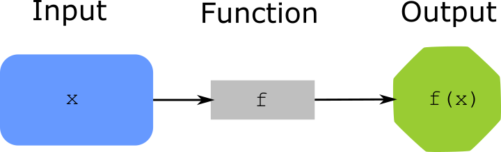

## Basic building blocks – Functions

- Each function consists of three parts.
  - A *name*
  - A list of *arguments*
  - A *body* of R code that processes the arguments

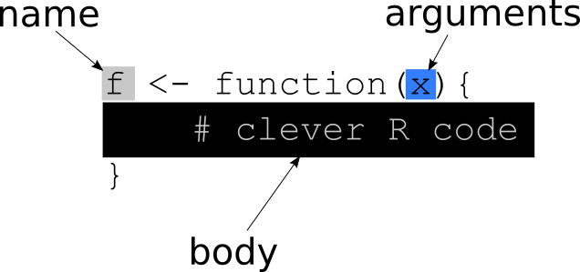

## Getting help

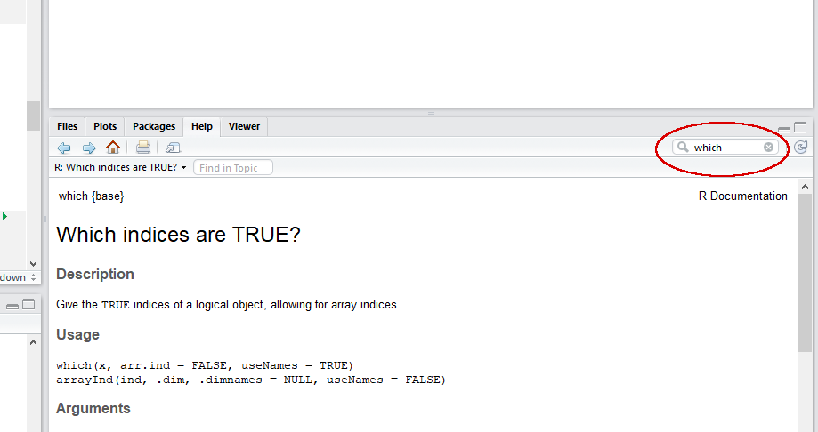

- Use RStudio's help browser.
- Use the `?` command (`?which`).
- Check RStudio cheat sheets.
- Look at the help page for the `which` function.
- What does the function do?
- How do you use it?

A lot of useful information is available online. Take a look at [rseek.org](http://rseek.org/).

## Getting help

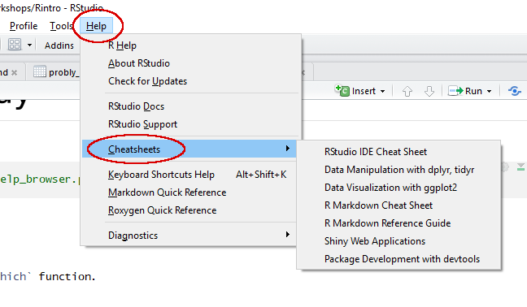

- Use RStudio's help browser.
- Use the `?` command (`?which`).
- Check RStudio cheat sheets.
- Look at the help page for the `which` function.
- What does the function do?
- How do you use it?

A lot of useful information is available online. Take a look at [rseek.org](http://rseek.org/).

## Binders full of functions

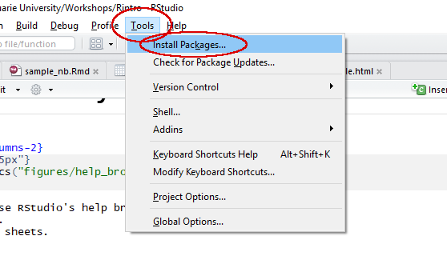

- R comes with a lot of useful functions build in.
- Additional functions are available through *packages*.
- Large collection available through public repositories.

```r
package_name::function_name()

library(package_name)
function_name()
```

## Working with data

## Working with variables

We can manipulate variables in multiple ways

- Arithmetic
- Comparison
- Combine, split, search

```r
x <- c(ans, ans/2, ans/3, ans/7)
y <- x*x
z <- x + y
p1 <- z/x
eq <- x == p1 - 1
small_idx <- which(x < 20)
small <- x[small_idx]
```

- `+`, `-`, `/`, `*` are arithmetic operators.
- `==`, `<`, `>`, `<=`, `>=` are comparison operators.
- `c` concatenates variables.
- `[` extracts subset of a vector.
- What happens if an operator is applied to a vector?

## Importing data

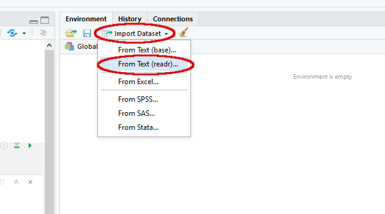

## Importing data

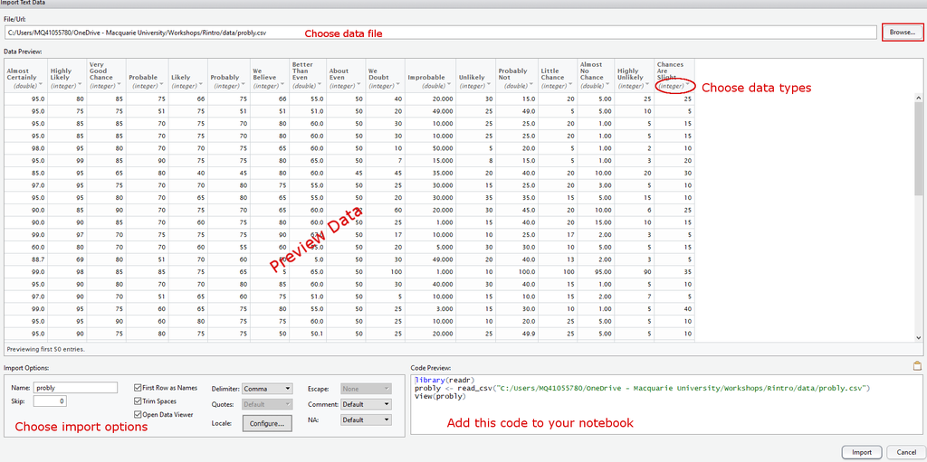

## The dataset

- Perception of uncertainty
  - *What probability would you assign to the phrase "[phrase]"*
- Collected by */u/zonination* on Reddit
- Inspired by [Sherman Kent](https://www.cia.gov/library/center-for-the-study-of-intelligence/csi-publications/books-and-monographs/psychology-of-intelligence-analysis/art15.html) study
- Available on [GitHub](https://github.com/zonination/perceptions)

## Tidying data

*Tidy* data should have

- One variable per column.
- One observation per row.
- What is the structure of the dataset?
- What are the rows/columns?
- Is this tidy data?

## Tidying data

It depends on the question we want to ask of the data!

- Each column could be considered a different level of the same variable.
- Or a different variable.
- Note that column with subject ID is missing.

## Using the `tidyr` package

Allows easy reformatting of data to make it tidy.

```r
library(tidyverse)
```

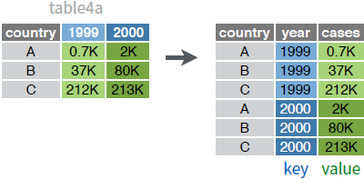

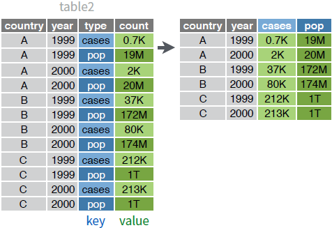

```r
gather(table4a, `1999`, `2000`,
       key = "year", value = "cases")
```

```r
spread(table2, type, count)
```

## Reshaping data

Tidy up the *probly* dataset by gathering all reported probabilities into a single column. Don't forget to load the `tidyverse` package.

First add a *subject* column.

```r
probly <- add_column(probly, subject=1:nrow(probly), .before=1)
```

```r
probly_long <- gather(probly, `Almost Certainly`:`Chances Are Slight`,
                      key="phrase", value="probability")
```

## Plotting with `ggplot2`

- A plot only really needs three things
  - data
  - mapping of data to geometric objects
  - coordinate system
- `ggplot2` provides an easy way to combine these elements into plots.

`ggplot(` data`) + geom_` type`(aes(` aesthetics`))`

**data**: a `data.frame` with your data.

**geom**: Geometric object to use to visualise the data.

**aesthetics**: Mapping of variables to properties of the *geom* (location, colour, size, …)

## Plotting data

Create a simple box plot of the data.

```r
library(ggplot2)
```

Use `geom_boxplot`

## Plotting data

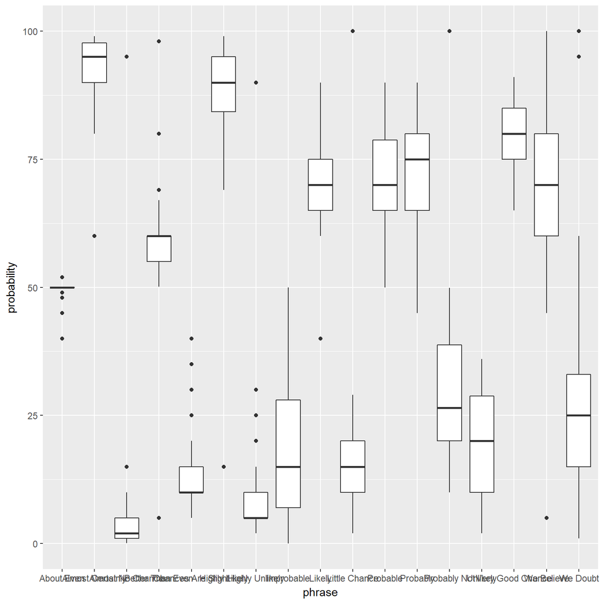

```r
ggplot(probly_long) + geom_boxplot(aes(x=phrase, y=probability))
```

## Improving the box plot

- Can't really read the labels. Can we fix that?

Take a look at the help page for `geom_boxplot`, the examples may provide inspiration.

## Improved box plot

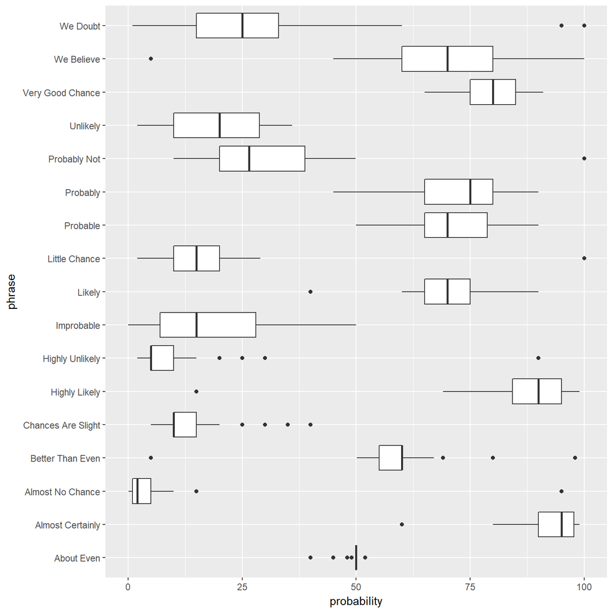

```r
ggplot(probly_long) + geom_boxplot(aes(x=phrase, y=probability)) + coord_flip()
```

## Improved box plot (alternative solution)

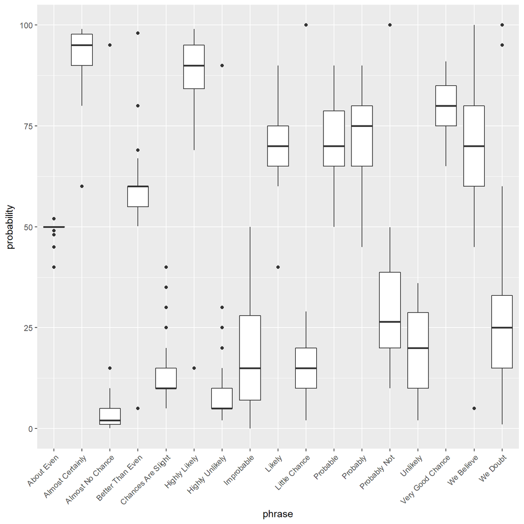

```r
ggplot(probly_long) + geom_boxplot(aes(x=phrase, y=probability)) +
  theme(axis.text.x=element_text(angle=45,hjust=1))
```

## Further improvements

- Plot is still hard to read.
- Would be helpful to order phrases by perceived probability.
- How do we tell `ggplot` which order to use?
- Factor levels are ordered alphabetically by default.
- The `forcats` package supports reordering factor levels based on another variable.

```r
library(forcats)
```

## Ordered plot

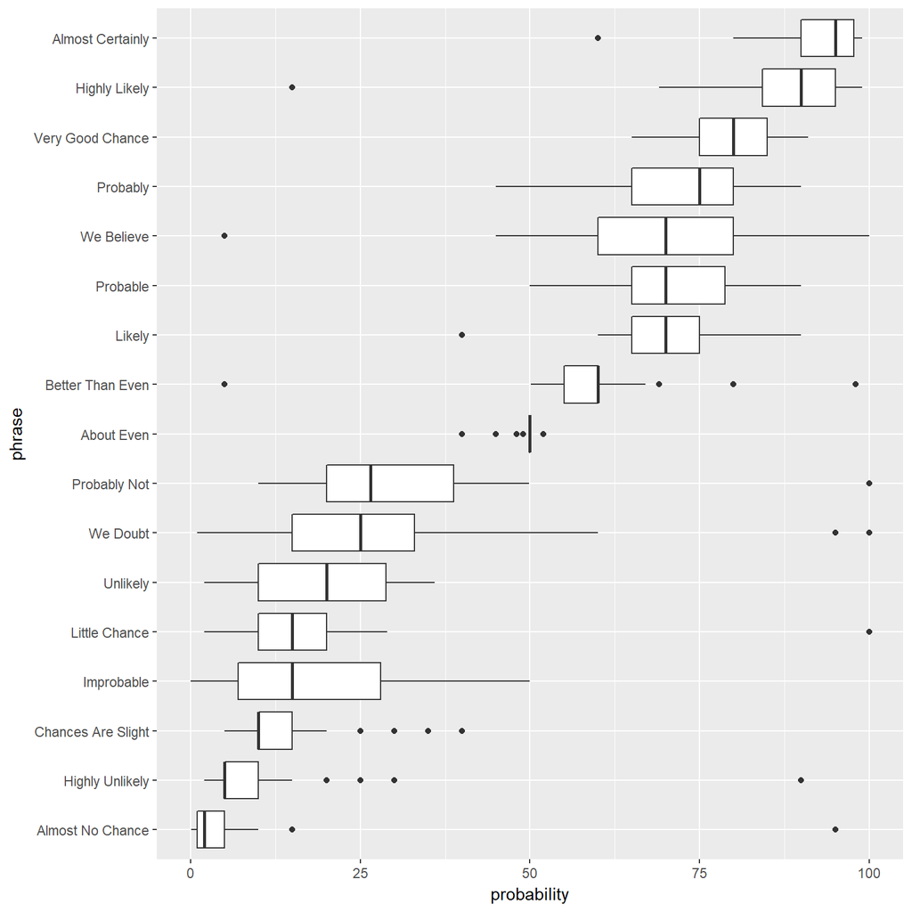

```r
probly_long <- mutate(probly_long, phrase=fct_reorder(phrase, probability))
ggplot(probly_long) + geom_boxplot(aes(x=phrase,
                                       y=probability)) + coord_flip()
```

## Final tweaks

1. Fix the y axis label.
2. Use colour to highlight differences between categories.

Search the help system for a way to change the axis label.

The `xlab` and `ylab` function will set the axis labels. Remember that we flipped the coordinate system.

```r
ggplot(probly_long) + geom_boxplot(aes(x=phrase,
                                       y=probability)) +
  xlab("") + coord_flip()
```

## Final tweaks

1. Fix the y axis label.
2. Use colour to highlight differences between categories.
- Group observations by phrase using the `group_by` function.
- New variables can be added with the `mutate` function.

```r
probly_long <- group_by(probly_long, phrase)
probly_long <- mutate(probly_long, avg=median(probability))
```

## Coloured plot

```r
ggplot(probly_long) + geom_boxplot(aes(x=phrase,
                                       y=probability,
                                       fill=avg)) +
  xlab("") + coord_flip()
```

## Coloured plot

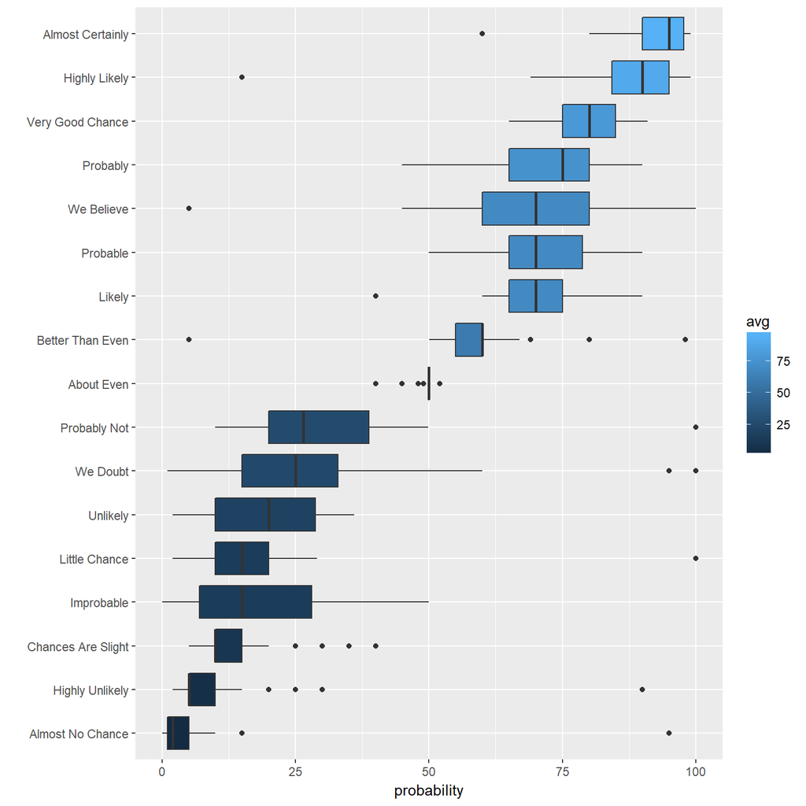

## Adjusting scales

- `ggplot` chose a single colour gradient to visualise median probabilities.
- A divergent scale centred on 50% would make a lot more sense.
- Scales for *aesthetics* can be adjusted via `scale` functions.
- `scale_` aesthetic`_`type
- scale types include *manual*, *discrete*, *continuous*, …

`scale_fill_gradient2(midpoint=50)`

## Final plot

```r
ggplot(probly_long) + geom_boxplot(aes(x=phrase,
                                       y=probability, fill=avg)) +
  xlab("") + coord_flip() +
  scale_fill_gradient2(midpoint=50)
```

## Final plot

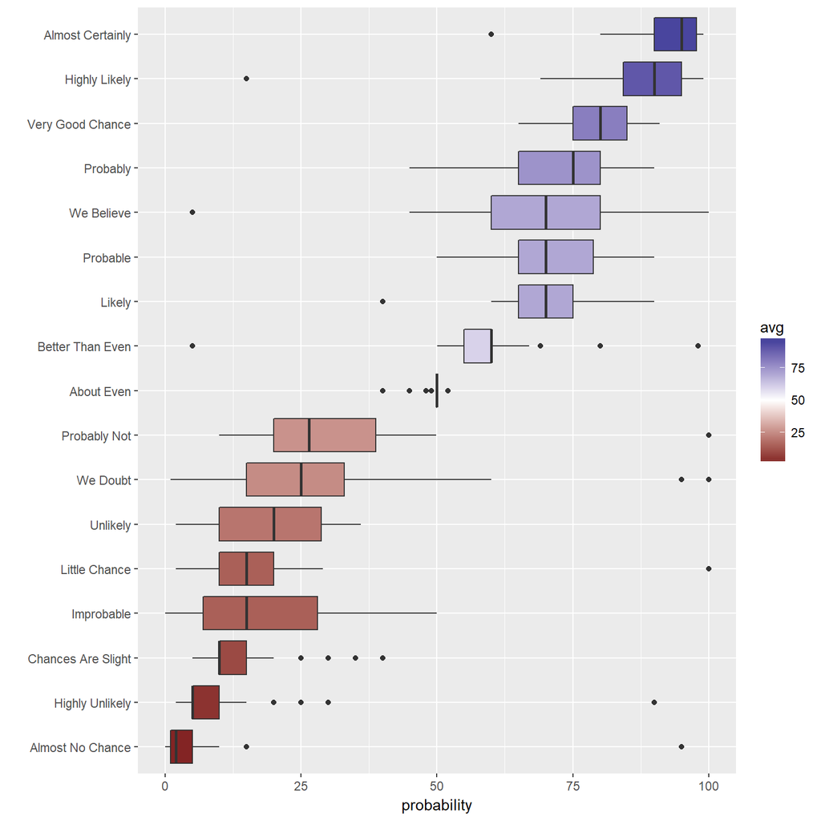

## Data cleaning

## Cleaning messy data

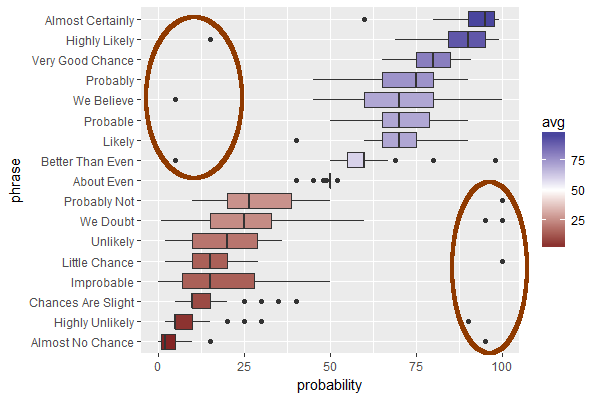

- Data are often messy
- Do unexpected outliers contain valuable information or are they just noise?
- What could we do to investigate?

## Plotting individual level data

It may be helpful to inspect individual responses. Create a plot that facilitates comparison between individual and average responses for each phrase.

## A possible solution

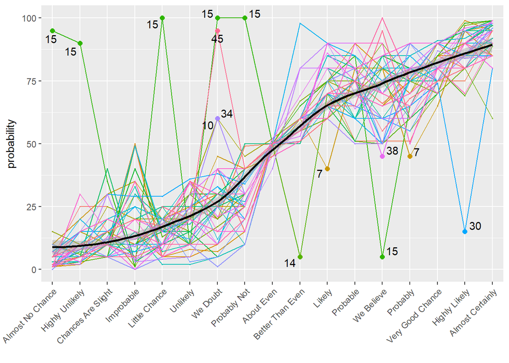

## A possible solution

```r
library(ggrepel)
phrase_count <- length(levels(probly_long$phrase))
probly_long <- mutate(probly_long, unexpected=sign(probability - 50) != sign(avg -50) &
                        probability != 50 & avg != 50)
ggplot(probly_long, aes(x=as.numeric(phrase),
                        y=probability)) +
  geom_line(aes(colour=factor(subject))) +
  geom_point(aes(colour=factor(subject), shape=unexpected, size=unexpected)) +
  geom_smooth(method="loess", colour='black') +
  geom_text_repel(data=filter(probly_long, unexpected),
                  aes(x=as.numeric(phrase),
                      y=probability,
                      label=subject)) +
  scale_x_continuous(breaks=1:phrase_count,
                     labels=levels(probly_long$phrase),
                     minor_breaks = NULL,
                     expand = c(0, 0.4)) +
  scale_size_manual(values=c(0, 2)) +
  scale_shape_manual(values=c(0, 16)) +
  guides(colour='none', shape='none', size='none') + xlab("") +
  theme(axis.text.x=element_text(angle=45,hjust=1))
```

## Removing unreliable measurements

- Be careful about removing outliers
- Outliers *may* be due to corrupted measurements
- but may also represent higher than expected variability in the data
- **Only** remove outliers if there is solid evidence that these measurements are unreliable
- Remove subject 15 from the dataset.
- Create plots for the cleaned data.

## Cleaned data

```r
probly_clean <- filter(probly_long, subject != 15)
```

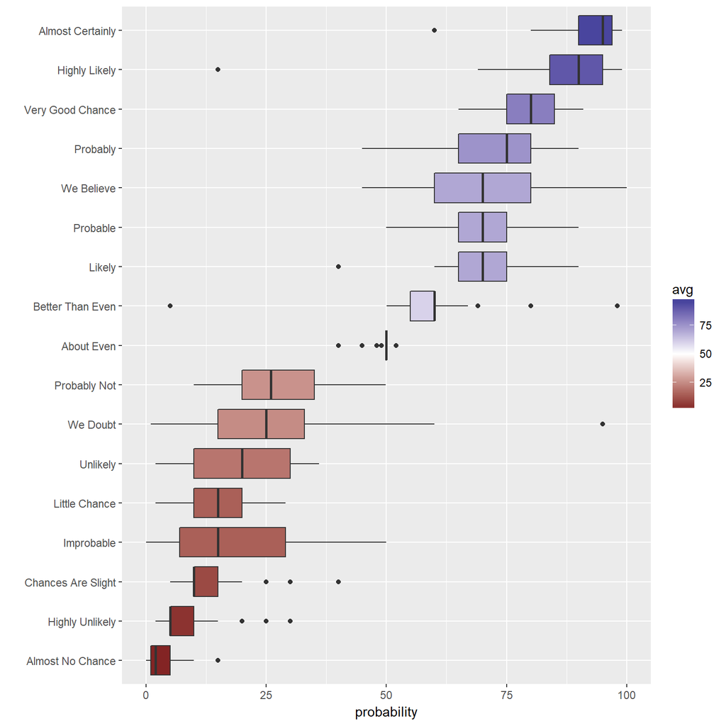

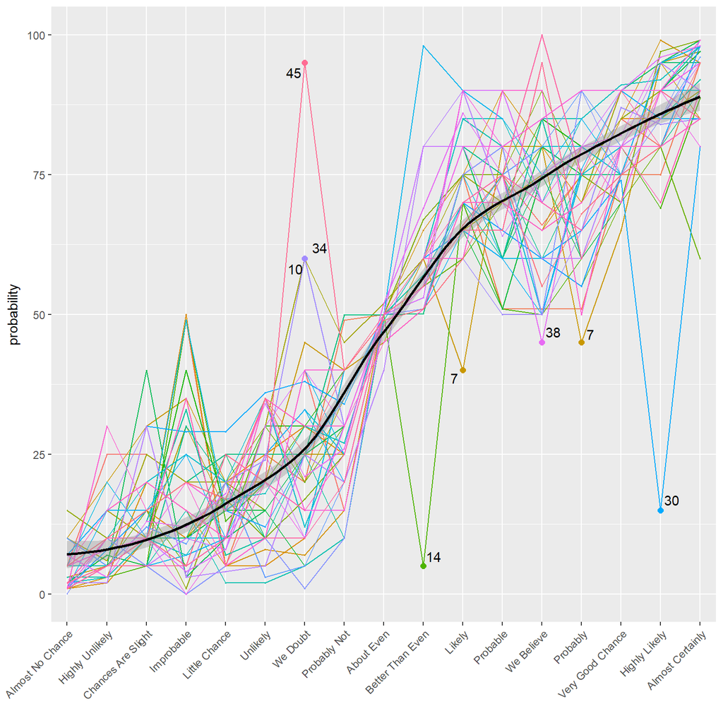

## Summarising data

## Getting the numbers

- Plots are very useful but sometimes we need actual numbers.
- Simple summaries can easily be obtained *via* `dplyr::summarise`

```r
 prob_summary <- summarise(probly_clean, mean=mean(probability))
```

|  | phrase | mean |
| --- | --- | --- |
| 1 | Almost No Chance | 3.65 |
| 2 | Highly Unlikely | 8.36 |
| 3 | Chances Are Slight | 13.62 |
| 4 | Improbable | 18.4 |
| 5 | Little Chance | 14.11 |
| 6 | Unlikely | 20.16 |
| 7 | We Doubt | 26.27 |
| 8 | Probably Not | 27.91 |
| 9 | About Even | 49.56 |
| 10 | Better Than Even | 58.25 |

[output cut: 7 more lines]

## More numbers

- Compute additional summary statistics.
- You could try *median*, *trimmed mean*, *standard deviation*, *inter quartile range*, *median absolute deviation*

`summarise` can produce multiple summaries at once.

## More numbers

```r
prob_summary <- summarise(probly_clean, mean=mean(probability),
                          sd=sd(probability),
                          'trimmed mean'=mean(probability, trim = 0.1),
                          median=median(probability), IQR=IQR(probability),
                          MAD=mad(probability))
```

|  | phrase | mean | sd | trimmed mean | median | IQR | MAD |
| --- | --- | --- | --- | --- | --- | --- | --- |
| 1 | Almost No Chance | 3.65 | 3.1 | 3.14 | 2 | 4 | 1.48 |
| 2 | Highly Unlikely | 8.36 | 6.23 | 7.32 | 5 | 5 | 2.97 |
| 3 | Chances Are Slight | 13.62 | 8.47 | 12.51 | 10 | 5 | 7.41 |
| 4 | Improbable | 18.4 | 14.31 | 16.95 | 15 | 22 | 14.83 |
| 5 | Little Chance | 14.11 | 6.76 | 13.92 | 15 | 10 | 7.41 |
| 6 | Unlikely | 20.16 | 10.05 | 20.3 | 20 | 20 | 14.83 |
| 7 | We Doubt | 26.27 | 17.19 | 24.49 | 25 | 18 | 14.83 |
| 8 | Probably Not | 27.91 | 10.5 | 27.89 | 26 | 15 | 8.9 |
| 9 | About Even | 49.56 | 1.88 | 49.95 | 50 | 0 | 0 |
| 10 | Better Than Even | 58.25 | 11.88 | 57.76 | 60 | 5 | 7.41 |

[output cut: 7 more lines]

## Is an event with *better than even* odds *likely*?

- We can use these data to determine whether the perception of two phrases differs significantly.

Investigate the difference between *Better Than Even* and *Likely*.

Use data in *wide* format (one column for each phrase).

A *paired t-test* should be useful here.

## Is an event with *better than even* odds *likely*?

```r
t.test(probly$Likely[-15], probly$`Better Than Even`[-15], paired=TRUE)
```

```
##
##  Paired t-test
##
## data:  probly$Likely[-15] and probly$`Better Than Even`[-15]
## t = 7.1021, df = 44, p-value = 8.102e-09
## alternative hypothesis: true difference in means is not equal to 0
## 95 percent confidence interval:
##   9.802789 17.570544
## sample estimates:
## mean of the differences
##                13.68667
```

## The Road Ahead

## Further adventures in R

- Continue to practice using R
- Explore your own data
- Learn about your favourite analysis techniques in R
- CRAN maintains lists of useful and recommended packages by topic
  - [Social Sciences](https://cran.r-project.org/web/views/SocialSciences.html)
  - [Psychometrics](https://cran.r-project.org/web/views/Psychometrics.html)
  - [Official Statistics](https://cran.r-project.org/web/views/OfficialStatistics.html) (including survey methodology)
  - [Bayesian Inference](https://cran.r-project.org/web/views/Bayesian.html)

## Useful packages

- Power analysis:
  - [`pwr`](https://cran.r-project.org/package=pwr)
  - [`skpr`](https://cran.r-project.org/package=skpr)
  - [`simr`](https://cran.r-project.org/package=simr)
- Linear (mixed) models: [`lme4`](https://cran.r-project.org/package=lme4)
- Non-linear regression: [`nlme`](https://cran.r-project.org/package=nlme)
- Eye tracking: [`eyetrackingR`](http://www.eyetracking-r.com/)
- Factor analysis/SEM: [`lavaan`](http://lavaan.ugent.be/)
- Bayesian hypothesis testing: [`BayesFactor`](http://bayesfactorpcl.r-forge.r-project.org/)

## This presentation

These slides are available at https://humburg.github.io/Rintro/

[figure not shown]